# Reproducible Research Course Progect 1

Kraev Anatoli

28 июня 2019 г

### About

This is the first project for the **Reproducible Research** course in Coursera’s Data Science specialization. This assignment makes use of data from a personal activity monitoring device (step counter). This device collects data at 5-minute intervals throughout the day. The data consists of two months of data from an anonymous individual collected during the months of October and November, 2012 and include the number of steps taken in 5-minute intervals each day.

The data for this assignment can be downloaded from the course web site.

The variables included in this dataset are: **steps**: Number of steps taking in a 5-minute interval (missing values are coded as `NA`) **date**: The date on which the measurement was taken in YYYY-MM-DD format **interval**: Identifier for the 5-minute interval in which measurement was taken

## Loading and preprocessing the data

For the preparation of data, the dplyr package was used.  
Loading as the data frame and create the data frame table.

```r
library(dplyr)
activity <- read.csv("repdata_data_activity/activity.csv", stringsAsFactors = FALSE)
activity <- tbl_df(activity)
summary(activity)
```

```
##      steps            date              interval
##  Min.   :  0.00   Length:17568       Min.   :   0.0
##  1st Qu.:  0.00   Class :character   1st Qu.: 588.8
##  Median :  0.00   Mode  :character   Median :1177.5
##  Mean   : 37.38                      Mean   :1177.5
##  3rd Qu.: 12.00                      3rd Qu.:1766.2
##  Max.   :806.00                      Max.   :2355.0
##  NA's   :2304
```

```r
activity$date <- as.Date(activity$date)
```

## What is mean total number of steps taken per day?

Create the number of steps taken each day by the histogram, and calculate the mean and the median value.

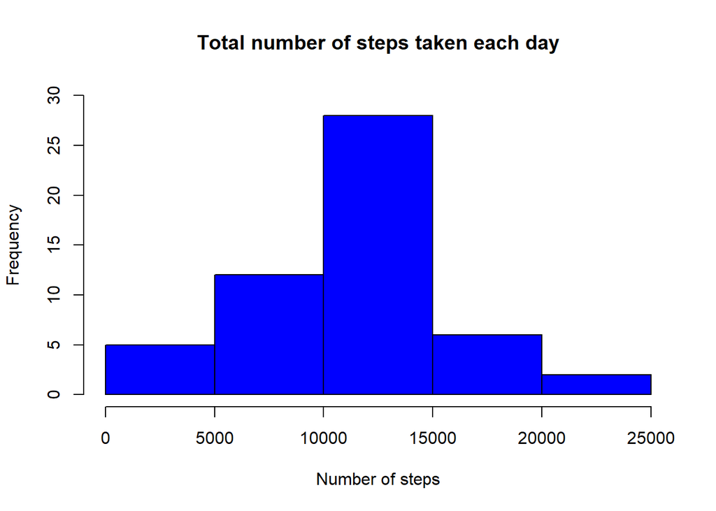

```r
activity_date <- group_by(activity, date)

sum_steps <- summarise(activity_date, sum_s = sum(steps, na.rm = TRUE))
sum_steps <- filter(sum_steps, sum_s > 0)

hist(sum_steps$sum_s, ylim = c(0,30), col = "blue", xlab = "Number of steps", main = "Total number of steps taken each day")
```

The mean of the total number of steps taken per day:

```r
mean(sum_steps$sum_s)
```

```
## [1] 10766.19
```

The median of the total number of steps taken per day:

```r
median(sum_steps$sum_s)
```

```
## [1] 10765
```

## What is the average daily activity pattern?

Make a time series plot of the 5-minute interval (x-axis) and the average number of steps taken, averaged across all days (y-axis).

```r
activity_interval <- group_by(activity, interval)
mean_interval <- summarise(activity_interval, mean_i = mean(steps, na.rm = TRUE))
mean_interval
```

```
## # A tibble: 288 x 2
##    interval mean_i
##       <int>  <dbl>
##  1        0 1.72
##  2        5 0.340
##  3       10 0.132
##  4       15 0.151
##  5       20 0.0755
##  6       25 2.09
##  7       30 0.528
##  8       35 0.868
##  9       40 0
## 10       45 1.47
## # ... with 278 more rows
```

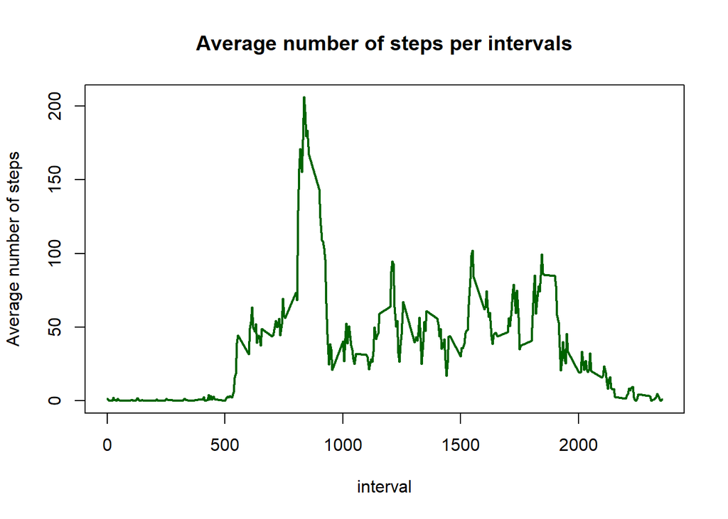

```r
with(mean_interval, plot(interval, mean_i, type="l", lwd = 2, col = "darkgreen", ylab = "Average number of steps", main = "Average number of steps per intervals"))
```

Which is 5-minute interval, on average across all the days in the dataset, contains the maximum number of steps?

```r
mean_interval[which.max(mean_interval$mean_i), ]$interval
```

```
## [1] 835
```

## Imputing missing values

The total number of missing values in the dataset:

```r
sum(!complete.cases(activity))
```

```
## [1] 2304
```

Creating is the new dataset that is equal to the original dataset but with the missing data filled in. For filling NA used mean value.

```r
activity_mean <- mutate(activity_interval,Mean=mean(steps,na.rm=TRUE),steps=replace(steps,which(is.na(steps)),first(Mean)))

sum_steps_noNA <- group_by(activity_mean, date)
sum_steps_noNA <- filter(sum_steps_noNA, steps > 0)

sum_steps_noNA1 <- summarize(sum_steps_noNA,sum_s=sum(steps))
sum_steps_noNA1
```

```
## # A tibble: 61 x 2
##    date        sum_s
##    <date>      <dbl>
##  1 2012-10-01 10766.
##  2 2012-10-02   126
##  3 2012-10-03 11352
##  4 2012-10-04 12116
##  5 2012-10-05 13294
##  6 2012-10-06 15420
##  7 2012-10-07 11015
##  8 2012-10-08 10766.
##  9 2012-10-09 12811
## 10 2012-10-10  9900
## # ... with 51 more rows
```

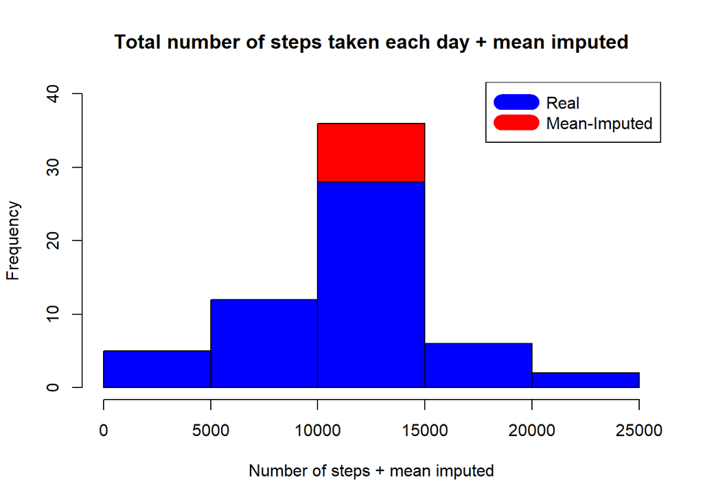

```r
hist(sum_steps_noNA1$sum_s,ylim = c(0,40), col = "red", xlab = "Number of steps + mean imputed", main = "Total number of steps taken each day + mean imputed")
hist(sum_steps$sum_s,ylim = c(0,40), col = "blue", add = TRUE)
legend("topright", c("Real", "Mean-Imputed"), col=c("blue", "red"), lwd=15)
```

## Are there differences in activity patterns between weekdays and weekends?

Creating the new factor variable in the dataset with two levels - “weekday” and “weekend” indicating whether a given date is a weekday or weekend.

```r
activity_weekdays <- mutate(sum_steps_noNA, weekday = weekdays(date))
activity_weekdays$weekday[!activity_weekdays$weekday == "воскресенье" & !activity_weekdays$weekday == "суббота"] <- "Weekday"
activity_weekdays$weekday[activity_weekdays$weekday == "воскресенье" | activity_weekdays$weekday == "суббота"] <- "Weekend"
activity_weekdays2 <- group_by(activity_weekdays, interval, weekday)
activity_weekdays2_sum <- summarise(activity_weekdays2, mean2 = mean(steps))
```

For plotting used the lattice package.

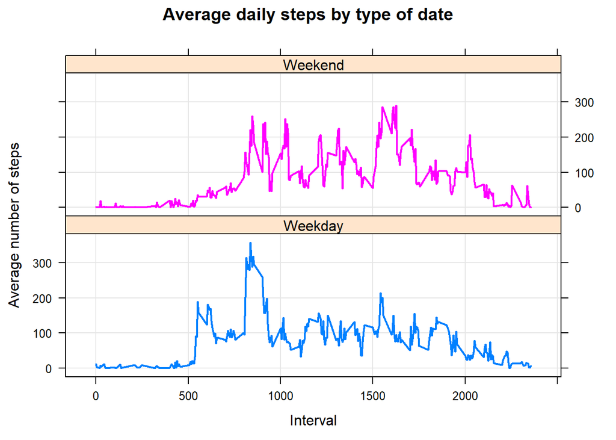

```r
library(lattice)
xyplot(mean2 ~ interval | weekday, data = activity_weekdays2_sum, layout = c(1,2), type = "l", grid = TRUE, group = weekday,
       ylab = "Average number of steps", xlab = "Interval", lwd = 2, main = "Average daily steps by type of date")
```